# Disease Transmission

Dan Conroy-Beam

2023-09-07

## Model Overview

### Purpose

A simple model of infectious disease transmission. Agents will move around a 2-dimensional surface and potentially spread an infectious disease to those nearby.

The model will manipulate the number of agents who move vs. stay in place (i.e. social distance) and observe the effect of social distancing on disease spread.

### Agents

A population of 200 agents will be generated. Agents will have a random position on a 2D surface.

Each agent will have an infection status (either susceptible, infected, or recovered); all but one agent will start the model as susceptible. One agent will start as infected.

All agents will also have a variable that tracks the number of days they have been infected; this will start at 0 for uninfected agents and 1 for infected agents.

Finally, all agents will possess a variable that reflects whether they are social distancing or not.

The proportion of agents that are social distancing will be set by a social distancing parameter.

### Life Cycle

1. Move
2. Infect
3. Recover

#### Move

Agents will move in a random direction. The distance they move on each day of the life cycle will be set by a movement speed parameter.

Agents that are social distancing will not move

#### Infect

Infected agents will potentially transmit the disease to susceptible agents nearby them.

Only agents within a certain radius of an infected agent are at risk of transmission;

This radius will be set as a parameter.

The probability of infecting each agent within this radius will also be set by a transmission probability parameter.

Only susceptible agents can be infected; infected and recovered agents cannot be re-infected

#### Recovery

The infection duration will increment by 1 each day an agent is infected.

When the total duration exceeds an infection duration parameter, the agent will change status to recovered

### Analysis

The model will save the proportion of the population that is susceptible, infected, and recovered each day

These will be plotted as a function of time to observe both the rate of disease spread and the peak infected proportion as a function of the social distancing parameter.

## Model

### Packages

```r
library(ggplot2)
```

### Parameters

```r
#Number of Days#
#Total number of times to repeat the life cycle
numDays<-100


#Population Size#
#Number of agents to generate
popSize<-200



#Proportion Social Distancing#
#The proportion of agents who are social distancing
propDistancing<-0



#Movement Speed#
#The distance agents travel in a given day
moveSpeed<-12



#Infection Radius#
#The radius within which the disease can be transmitted
radius<-6



#Contagiousness#
#Probability of spreading the infection on any given contact
contagion<-.5



#Infection Duration#
#The total number of days before an agent recovers from an infection
infectionDuration<-14
```

### Functions

```r
#Agent Generation#
#A function to generate agents
agentGenerate<-function(n,p){

  #n = population size
  #p = proportion social distancing

  #Generate agents a random position on a 2-D surface
  xPos<-runif(n,0,100)
  yPos<-runif(n,0,100)

  #Assign each agent a social distancing status
  #1 = social distancing (staying put)
  #0 = not distancing (moving around)
  distancing<-sample(c(rep(1,floor(n*p)),
    rep(0,n-floor(n*p))))

  #Set initial infection status
  status<-sample(c(rep("susceptible",n-1),"infected"))

  #Create a variable to track duration of infection
  daysInfected<-ifelse(status=="infected",1,0)

  #Put the agents together
  agents<-data.frame(xPos,
                     yPos,
                     distancing,
                     status,
                     daysInfected)

  #Output the agents
  return(agents)

}



#Movement#
#A function to move agents
move<-function(startX,startY,speed){

  #Generate a random squared movement on the X dimension
  xDiff<-runif(1,0,speed^2)

  #Generate the corresponding movement on the Y dimension
  yDiff<-speed^2-xDiff

  #Determine the overall movement on both dimensions
  movement<-c(sqrt(xDiff),sqrt(yDiff))

  #Randomly make each movement direction positive or negative
  movement<-sample(c(-1,1),replace=T)*movement

  #Generate the agents' new X and Y coordinates
  newPos<-movement+c(startX,startY)

  #Prevent agents from going above 100 or below 0
  newPos<-newPos %% 100

  #Output the agent's new position
  return(newPos)

}
```

### Life Cycle

```r
#Generate the agents
agents<-agentGenerate(popSize,propDistancing)


#Generate a blank dataframe to store model results
results<-data.frame("day"=1:numDays,
                    "status"=rep(c("susceptible",
                                   "infected",
                                   "recovered"),
                                 each=numDays),
                    "prop"=NA)


#Loop for the specified number of days
for (d in 1:numDays) {

  #Move#

  #Loops one-by-one through agents
  for (a in 1:popSize) {
    #If agents are not social distancing...
    if (agents$distancing[a] == 0) {
      #Have the agent move to a new position
      agents[a, 1:2] <- move(agents$xPos[a],
                             agents$yPos[a],
                             moveSpeed)

    }

  }



  #Infect#

  #Compute how far each agent is from every other agent
  distances <- as.matrix(dist(agents[, 1:2]))

  #Determine which agents are infected
  infected <- which(agents$status == "infected")

  #Loop through infected agents...
  for (i in infected) {
    #Determine which agents are within the infection radius
    risk <- distances[i, ] <= radius

    #Eliminate people who are not susceptible
    risk <- risk & agents$status == "susceptible"

    #Determine whether transmission actually happens
    transmission <- risk & rbinom(popSize, 1, contagion)

    #Change the status of agents who experienced a transmission
    agents$status[transmission] <- "infected"

  }



  #Recovery#

  #Increments days infected by 1 for infected agents
  agents$daysInfected[agents$status == "infected"] <-
    agents$daysInfected[agents$status == "infected"] + 1

  #If agents have been infected for more than the infection duration...switch their status to "recovered"
  agents$status <- ifelse(agents$daysInfected >
                            infectionDuration,
                          "recovered",
                          agents$status)




  #Store Data#

  #Store the proportion of agents who have each section
  results$prop[results$status=="susceptible" &
                 results$day==d]<-mean(agents$status=="susceptible")

  results$prop[results$status=="infected" &
                 results$day==d]<-mean(agents$status=="infected")

  results$prop[results$status=="recovered" &
                 results$day==d]<-mean(agents$status=="recovered")

}
```

### Analysis

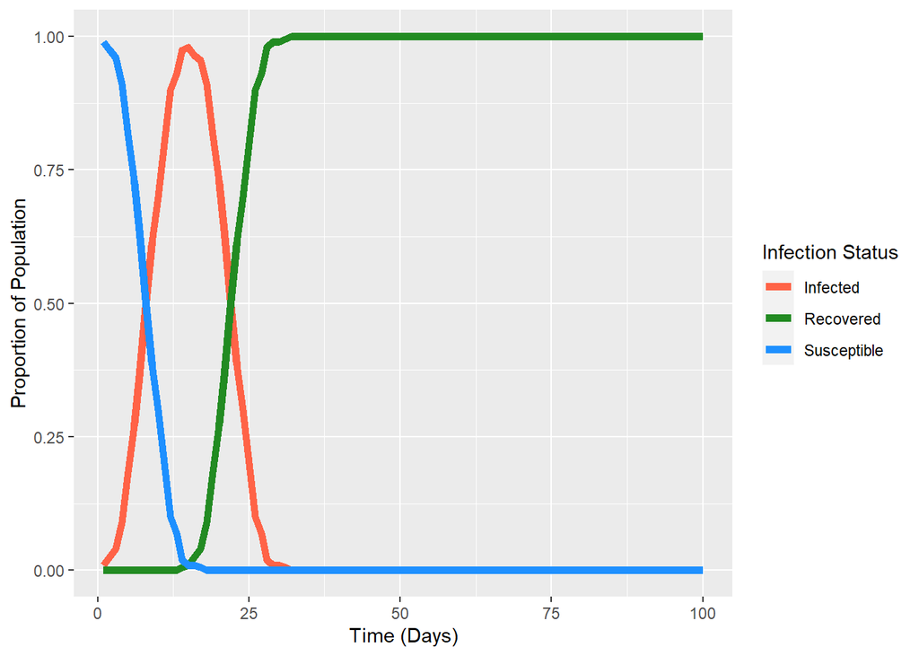

```r
#Generate the SIR plot
sirPlot<-ggplot(data=results,
                aes(x=day,
                    y=prop,
                    color=status))+
  labs(x="Time (Days)",
       y="Proportion of Population",
       color="Infection Status")+
  geom_line(lwd=2)+
  scale_color_manual(labels=c("Infected","Recovered","Susceptible"),
                     values=c("tomato","forestgreen","dodgerblue"))

sirPlot
```